# 01_exploratorio

Ita Santiago

15/8/2020

## Propinas

Los siguientes datos fueron registrados en un restaurante durante cuatro días consecutivos:

```r
library(tidyverse)
library(patchwork)
## Lee los datos
tips <- read_csv("tips.csv")
glimpse(tips)
```

```
## Rows: 244
## Columns: 8
## $ X1         <dbl> 1, 2, 3, 4, 5, 6, 7, 8, 9, 10, 11, 12, 13, 14, 15, 16, 1...
## $ total_bill <dbl> 16.99, 10.34, 21.01, 23.68, 24.59, 25.29, 8.77, 26.88, 1...
## $ tip        <dbl> 1.01, 1.66, 3.50, 3.31, 3.61, 4.71, 2.00, 3.12, 1.96, 3....
## $ sex        <chr> "Female", "Male", "Male", "Male", "Female", "Male", "Mal...
## $ smoker     <chr> "No", "No", "No", "No", "No", "No", "No", "No", "No", "N...
## $ day        <chr> "Sun", "Sun", "Sun", "Sun", "Sun", "Sun", "Sun", "Sun", ...
## $ time       <chr> "Dinner", "Dinner", "Dinner", "Dinner", "Dinner", "Dinne...
## $ size       <dbl> 2, 3, 3, 2, 4, 4, 2, 4, 2, 2, 2, 4, 2, 4, 2, 2, 3, 3, 3,...
```

```r
## Recodificar nombres y niveles
propinas <- tips %>%
  rename(cuenta_total = total_bill,
         propina = tip, sexo = sex,
         fumador = smoker,
         dia = day, momento = time,
         num_personas = size) %>%
  mutate(sexo = recode(sexo, Female = "Mujer", Male = "Hombre"),
         fumador = recode(fumador, No = "No", Si = "Si"),
         dia = recode(dia, Sun = "Dom", Sat = "Sab", Thur = "Jue", Fri = "Vie"),
         momento = recode(momento, Dinner = "Cena", Lunch = "Comida")) %>%
  select(-sexo) %>%
  mutate(dia  = fct_relevel(dia, c("Jue", "Vie", "Sab", "Dom")))
propinas
```

| X1 | cuenta_total | propina | fumador | dia | momento | num_personas |
| --- | --- | --- | --- | --- | --- | --- |
| 1 | 16.99 | 1.01 | No | Dom | Cena | 2 |
| 2 | 10.34 | 1.66 | No | Dom | Cena | 3 |
| 3 | 21.01 | 3.50 | No | Dom | Cena | 3 |
| 4 | 23.68 | 3.31 | No | Dom | Cena | 2 |
| 5 | 24.59 | 3.61 | No | Dom | Cena | 4 |
| 6 | 25.29 | 4.71 | No | Dom | Cena | 4 |
| 7 | 8.77 | 2.00 | No | Dom | Cena | 2 |
| 8 | 26.88 | 3.12 | No | Dom | Cena | 4 |
| 9 | 15.04 | 1.96 | No | Dom | Cena | 2 |
| 10 | 14.78 | 3.23 | No | Dom | Cena | 2 |

[output cut: 234 more lines]

### 1. Calcula percentiles de la variable propina junto con mínimo y máxio

```r
quantile(propinas$propina)
```

```
##      0%     25%     50%     75%    100%
##  1.0000  2.0000  2.9000  3.5625 10.0000
```

### 2. Haz una gráfica de cuantiles de la variable propina

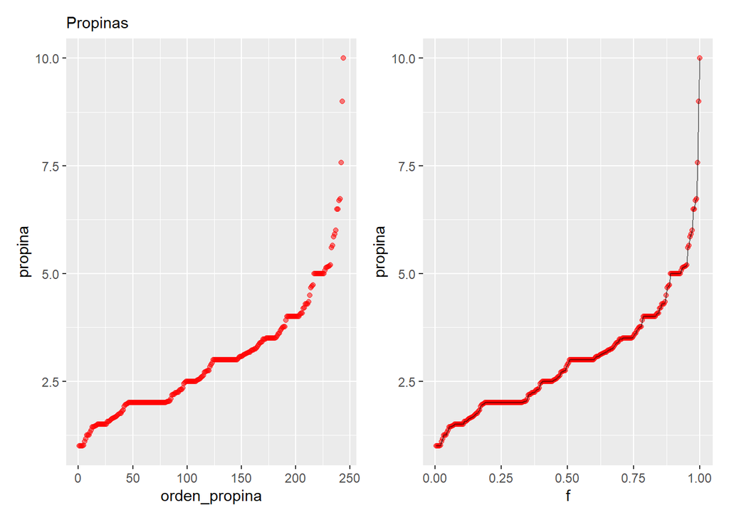

```r
propinas <- propinas %>%
  mutate(orden_propina = rank(propina, ties.method = "first"),
         f = orden_propina / n())

g_orden <- ggplot(propinas, aes(y = propina, x = orden_propina)) +
  geom_point(colour = "red", alpha = 0.5) +
  labs(subtitle = "Propinas")
g_cuantiles <- ggplot(propinas, aes(y = propina, x = f)) +
  geom_point(colour = "red", alpha = 0.5) +
  geom_line(alpha = 0.5) +
  labs(subtitle = "")
g_orden + g_cuantiles
```

### 3. Haz un histograma de la variable propinas

Ajusta distintos anchos de banda

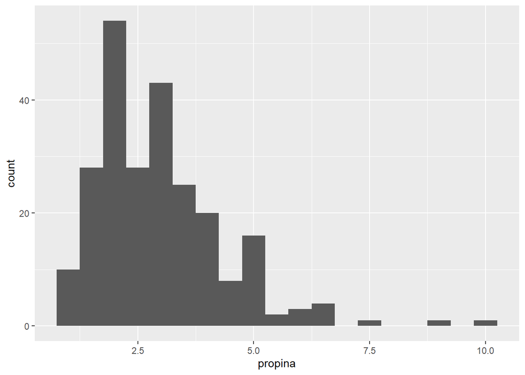

```r
ggplot(propinas, aes(x = propina)) +
  geom_histogram(binwidth = 0.5)
```

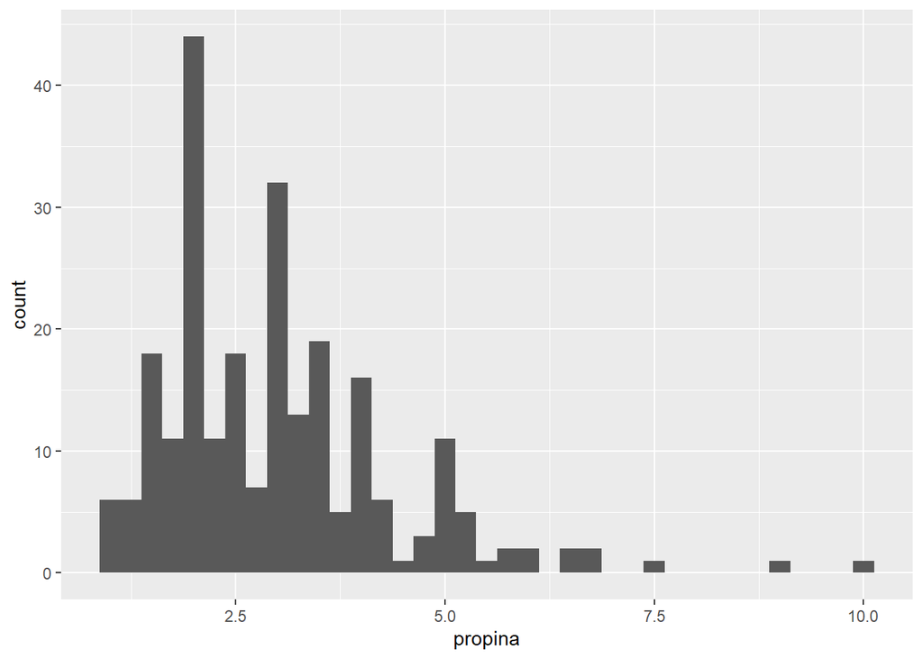

```r
ggplot(propinas, aes(x = propina)) +
  geom_histogram(binwidth = 0.25)
```

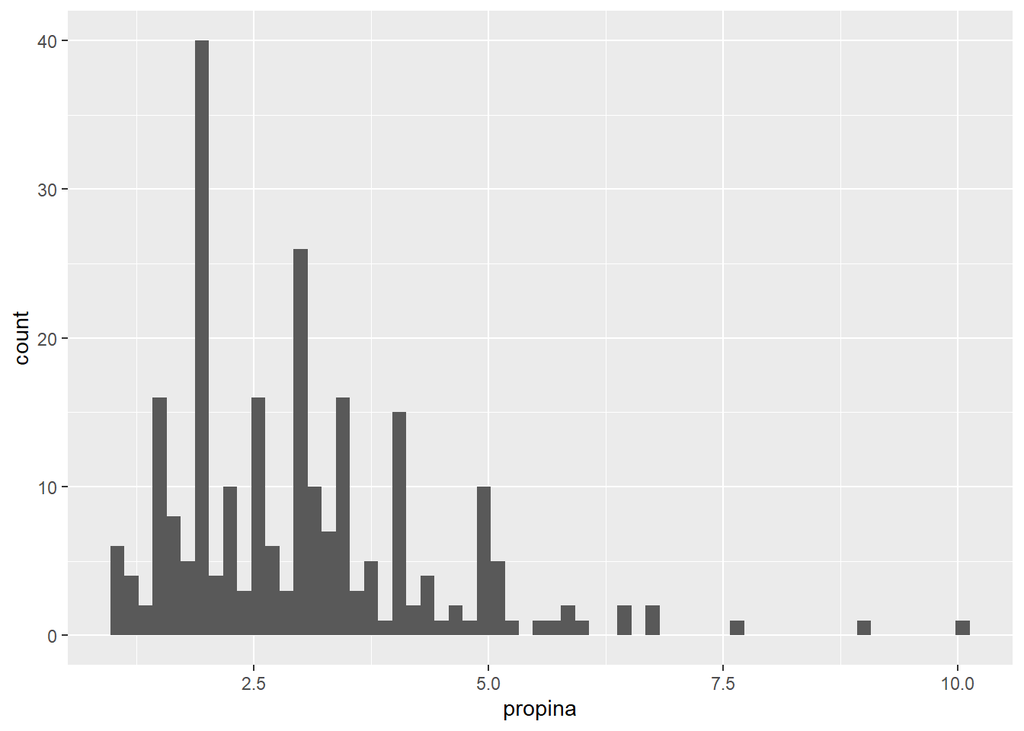

```r
ggplot(propinas, aes(x = propina)) +
  geom_histogram(binwidth = 0.15)
```

### 4. Haz una gráfica de cuenta total contra propina

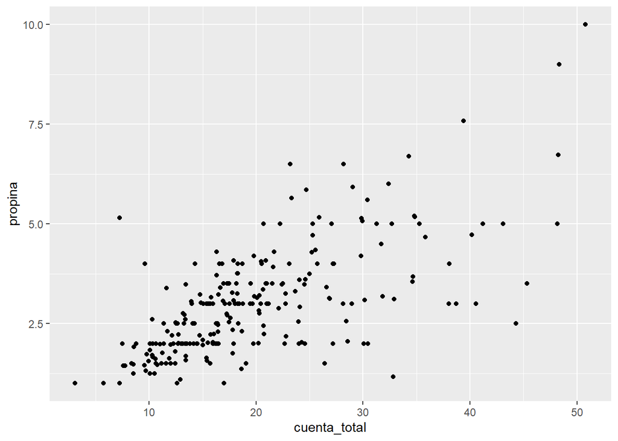

```r
ggplot(propinas, aes(x= cuenta_total, y = propina)) +
  geom_point()
```

### 5. Calcula propina en porcentaje de la cuenta total

calcula algunos cuantiles de propina en porcentaje

```r
propinas <- propinas %>%
  mutate(pct_propina = 100 * propina / cuenta_total)

quantile(propinas$pct_propina)
```

```
##        0%       25%       50%       75%      100%
##  3.563814 12.912736 15.476977 19.147549 71.034483
```

### 6. Haz un histograma de la propina en porcentaje.

Prueba con distintos anchos de banda.

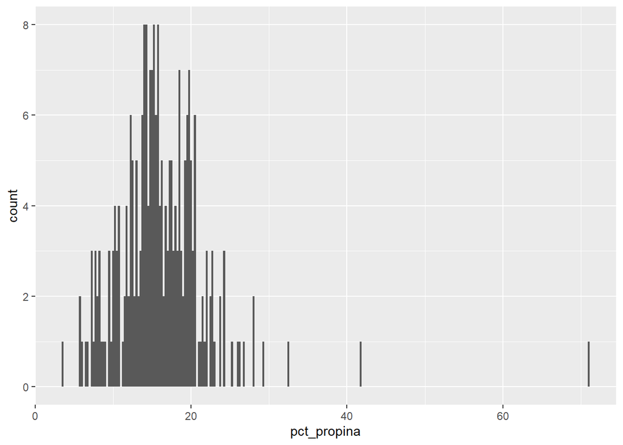

```r
ggplot(propinas, aes(x = pct_propina)) +
  geom_histogram(binwidth = 0.25)
```

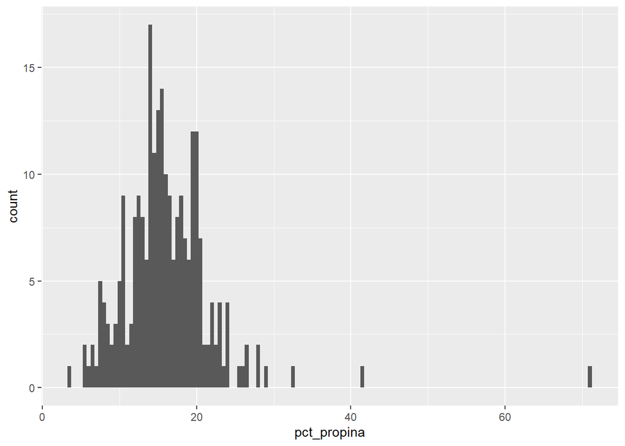

```r
ggplot(propinas, aes(x = pct_propina)) +
  geom_histogram(binwidth = 0.5)
```

### 7. Describe la distribución de propina en pct.

¿Hay datos atípicos?

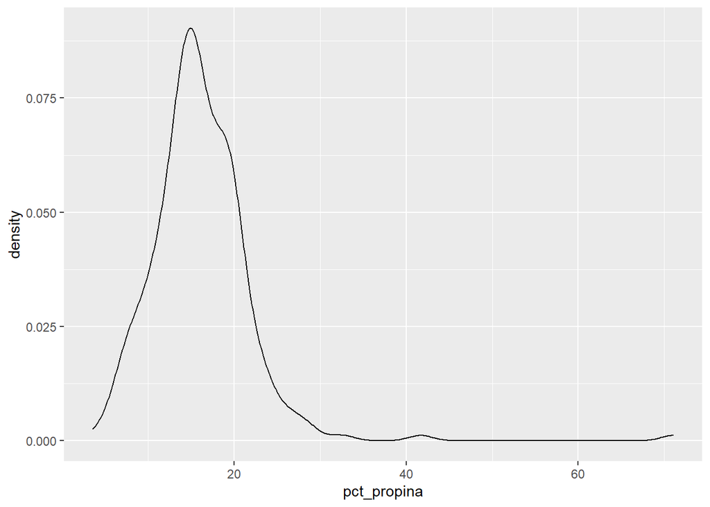

```r
ggplot(propinas, aes(x = pct_propina)) +
  geom_density()
```

### 8. Filtra los casos con porcentaje de propina muy altos.

¿Qué tipos de cuentas son? ¿Son cuentas grandes o chicas?

```r
head(arrange(propinas, desc(pct_propina)))
```

| X1 | cuenta_total | propina | fumador | dia | momento | num_personas | orden_propina | f | pct_propina |
| --- | --- | --- | --- | --- | --- | --- | --- | --- | --- |
| 173 | 7.25 | 5.15 | Yes | Dom | Cena | 2 | 229 | 0.938524590 | 71.03448 |
| 179 | 9.60 | 4.00 | Yes | Dom | Cena | 2 | 199 | 0.815573770 | 41.66667 |
| 68 | 3.07 | 1.00 | Yes | Sab | Cena | 1 | 1 | 0.004098361 | 32.57329 |
| 233 | 11.61 | 3.39 | No | Sab | Cena | 2 | 167 | 0.684426230 | 29.19897 |
| 184 | 23.17 | 6.50 | Yes | Dom | Cena | 4 | 238 | 0.975409836 | 28.05352 |
| 110 | 14.31 | 4.00 | Yes | Sab | Cena | 2 | 195 | 0.799180328 | 27.95248 |

```r
propinas %>%
  filter(pct_propina > 25)
```

| X1 | cuenta_total | propina | fumador | dia | momento | num_personas | orden_propina | f | pct_propina |
| --- | --- | --- | --- | --- | --- | --- | --- | --- | --- |
| 52 | 10.29 | 2.60 | No | Dom | Cena | 2 | 113 | 0.463114754 | 25.26725 |
| 68 | 3.07 | 1.00 | Yes | Sab | Cena | 1 | 1 | 0.004098361 | 32.57329 |
| 94 | 16.32 | 4.30 | Yes | Vie | Cena | 2 | 211 | 0.864754098 | 26.34804 |
| 110 | 14.31 | 4.00 | Yes | Sab | Cena | 2 | 195 | 0.799180328 | 27.95248 |
| 150 | 7.51 | 2.00 | No | Jue | Comida | 2 | 59 | 0.241803279 | 26.63116 |
| 173 | 7.25 | 5.15 | Yes | Dom | Cena | 2 | 229 | 0.938524590 | 71.03448 |
| 179 | 9.60 | 4.00 | Yes | Dom | Cena | 2 | 199 | 0.815573770 | 41.66667 |
| 184 | 23.17 | 6.50 | Yes | Dom | Cena | 4 | 238 | 0.975409836 | 28.05352 |
| 222 | 13.42 | 3.48 | Yes | Vie | Comida | 2 | 172 | 0.704918033 | 25.93145 |
| 233 | 11.61 | 3.39 | No | Sab | Cena | 2 | 167 | 0.684426230 | 29.19897 |

Se puede observar que en realidad no fueron cuentas grandes y la mayoría son cuentas en la “cena” y de los fumadores

### 9. Haz una diagrama de caja y brazos para propina en dolares dependiendo del momento (comida o cena)

¿Cuál parece más grande? ¿Por qué? Haz otras gráficas si es necesario.

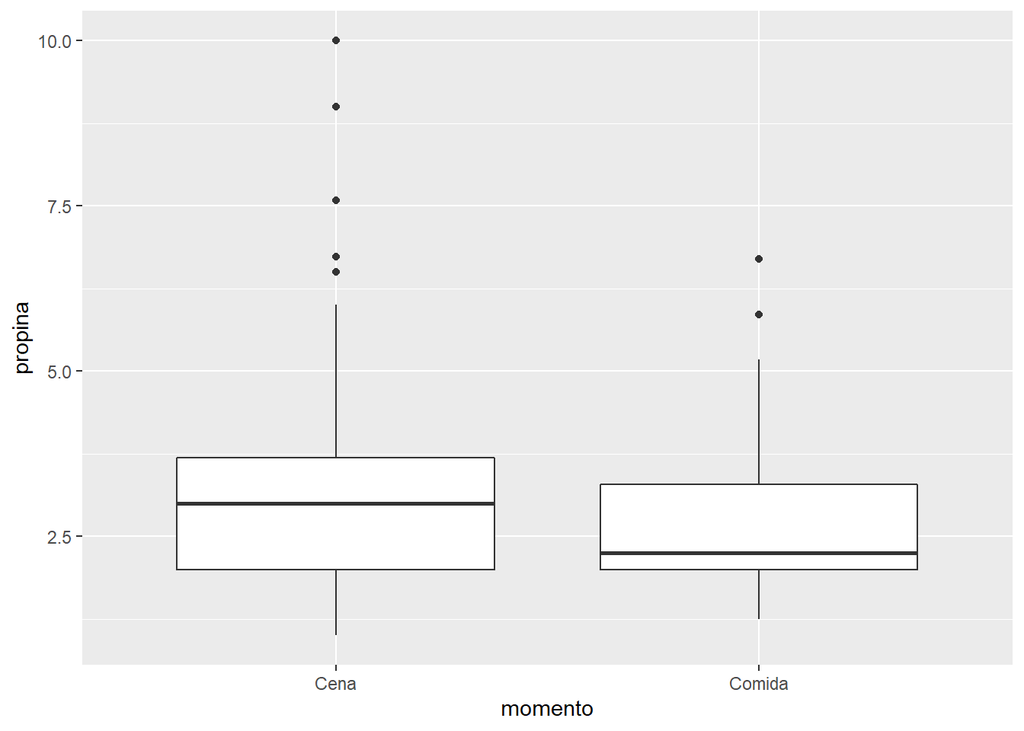

```r
ggplot(propinas, aes(x = propina, y = momento)) +
  geom_boxplot() +
  coord_flip()
```

El diagrama de caja de la cena es más grande, esto se debe a que las propinas de la cena están más dispersos a la mediana de las propinas de la cena. Incluso se puede ver que tiene más datos atípicos.

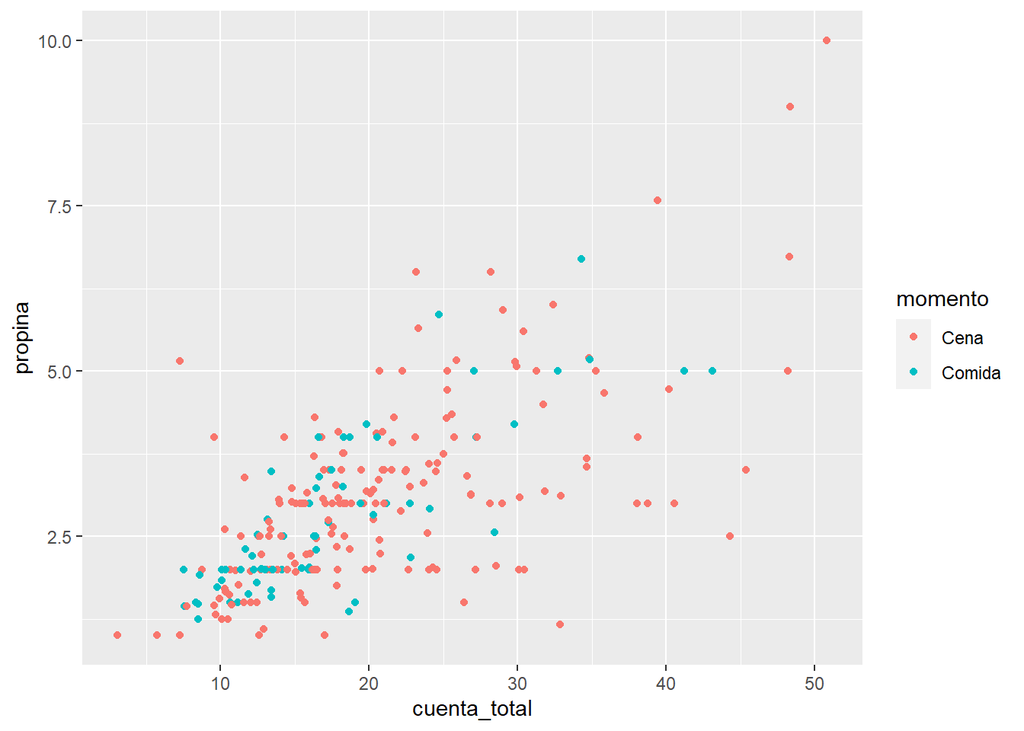

```r
ggplot(propinas, aes(x = cuenta_total, y = propina, group = momento)) +
  geom_point(aes(color = momento), size = 1.5)
```

En la gráfica anterior se puede observar que hay más propinas asignadas a las cuentas totales, aunque también podemos ver que son datos más dispersos.

A continuación se graficarán las densidades de las agrupaciones de “Cena” y “Comida”.

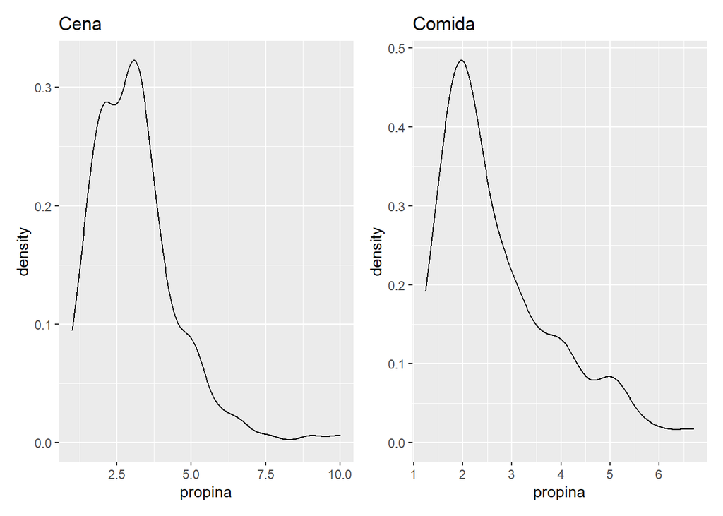

```r
cena <- propinas %>%
  filter(momento == 'Cena')

comida <- propinas %>%
  filter(momento == 'Comida')

g_cena <- ggplot(cena, aes(x = propina)) +
  geom_density() +
  ggtitle("Cena")

g_comida <- ggplot(comida, aes(x = propina)) +
  geom_density() +
  ggtitle("Comida")

g_cena + g_comida
```

Se puede observar que la curva que describe la distribución de “cena” es más ancha que la de comida, lo cual nos confirma que los datos están más “dispersos”